# omicsPrint: detection of data linkage errors in multiple omics studies

Maarten van Iterson

Department of Medical Statistics and Bioinformatics, Section Moleculair Epidemiology, Leiden University Medical Center, Leiden, The Netherlands  
mviterson@gmail.com

Davy Cats

Department of Medical Statistics and Bioinformatics, Section Moleculair Epidemiology, Leiden University Medical Center, Leiden, The Netherlands  
davycats.dc@gmail.com

Paul Hop

Department of Medical Statistics and Bioinformatics, Section Moleculair Epidemiology, Leiden University Medical Center, Leiden, The Netherlands  
pjhop@gmail.com

Bas T. Heijmans

Department of Medical Statistics and Bioinformatics, Section Moleculair Epidemiology, Leiden University Medical Center, Leiden, The Netherlands  
b.t.heijmans@lumc.nl

2017-12-14

Abstract

The Aanalysis of multiple omics datatypes from the same individuals is becoming increasingly common. For example, several data repositories contain genetic, transcriptomic and epigenetic (DNA methylation) measurements on the same individuals, e.g., TCGA, Geuvadis, BBMRI/BIOS, etc. However, errors in the data linkage are almost inevitable in such complex projects (e.g. due to sample mix-ups) and unknown family relationships may be present. If not corrected, such errors may introduce false positive or false negative findings. To streamline necessary quality control, we have developed a tool to reliably verify the sample relationships between and across omics data types using genotype data that is directly measured or inferred from for example RNA-seq or DNA methylation array data.

# Methylation Data

First we extract the data from GEO using the [*GEOquery*](http://bioconductor.org/packages/GEOquery/)-package and beta-values are extracted using the `exprs`-function:

```r
library(GEOquery)
library(SummarizedExperiment)
file <- tempfile()
download.file("ftp://ftp.ncbi.nlm.nih.gov/geo/series/GSE39nnn/GSE39672/matrix/GSE39672_series_matrix.txt.gz", file)
gset <- getGEO(filename=file)
```

```
## File stored at:
```

```
## /tmp/Rtmp7UGIDd/GPL13534.soft
```

```r
gset
```

```
## ExpressionSet (storageMode: lockedEnvironment)
## assayData: 485577 features, 133 samples
##   element names: exprs
## protocolData: none
## phenoData
##   sampleNames: GSM977267 GSM977268 ... GSM977399 (133 total)
##   varLabels: title geo_accession ... data_row_count (37 total)
##   varMetadata: labelDescription
## featureData
##   featureNames: cg00000029 cg00000108 ... rs9839873 (485577 total)
##   fvarLabels: ID Name ... SPOT_ID (37 total)
##   fvarMetadata: Column Description labelDescription
## experimentData: use 'experimentData(object)'
## Annotation: GPL13534
```

```r
se <- makeSummarizedExperimentFromExpressionSet(gset)
colnames(se) <- gsub("cell line: ", "", colData(se)$characteristics_ch1.2)
```

```r
population <- gsub("^.* ", "", colData(se)$characteristics_ch1)
table(population)
```

```
## population
## CEU YRI
##  60  73
```

If we would have had the raw idats we could extract the 65 SNPs. However, experiences show that the 65 SNPs available on the array are not enough to perform sample verification with high confidence. Fortunately, several probes on the array contain SNPs occuring frequently in different populations(Chen et al. 2013; Zhou, Laird, and Shen 2016).

We have made the data available from inside of this package package in a `GRanges`-object.

Now we make a selection of CpGs probably affected by polymorphic SNPS in these two populations:

```r
library(omicsPrint)
library(GenomicRanges)
data(hm450.manifest.pop.GoNL)
cpgs <- names(hm450.manifest.pop.GoNL[mcols(hm450.manifest.pop.GoNL)$MASK.snp5.CEU
                                      | mcols(hm450.manifest.pop.GoNL)$MASK.snp5.YRI])
```

Next the beta-values are converted to genotypes using our enhanced K-means algorithm:

```r
dnamCalls <- beta2genotype(se[cpgs,], assayName = "exprs")
dim(dnamCalls)
```

```
## [1] 1060  133
```

```r
dnamCalls[1:5, 1:5]
```

```
##            NA19147 NA12750 NA18916 NA12146 NA12057
## cg06624358       1       1       1       1       3
## cg13917577       1       3       1       3       2
## cg11853970       3       3       3       3       3
## cg04891761       2       1       1       3       2
## cg25619287       3       3       1       3       3
```

```r
save(dnamCalls, file="dnamCalls.RData")
load("dnamCalls.RData")
```

The DNA methylation based genotype calls can directly supplied to the allelesharing algorithm to perform the intra-omic sample matching:

```r
data <- alleleSharing(dnamCalls)
```

```
## Hash relations
```

```
## Pruning 1060 SNPs ...
```

```
## 0 SNPs removed because of low call rate!
```

```
## 0 samples removed because too few SNPs called!
```

```
## Using 1060 polymorphic SNPs to determine allele sharing.
```

```
## Running `square` IBS algorithm!
```

```
## 134 of 8911 (1.5%) ...
```

```
## 8351 of 8911 (93.72%) ...
```

```r
mismatches <- inferRelations(data)
```

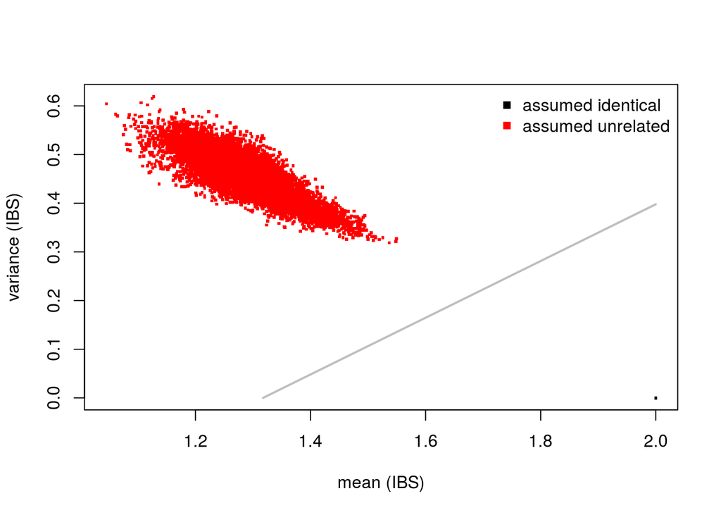

```r
nrow(data) ##number of pairs
```

```
## [1] 8911
```

```r
ncol(dnamCalls) ##identical
```

```
## [1] 133
```

```r
ncol(dnamCalls)*(ncol(dnamCalls) - 1)/2 ##non-identical
```

```
## [1] 8778
```

```r
ncol(dnamCalls)*(ncol(dnamCalls) + 1)/2 ##total
```

```
## [1] 8911
```

There are no unknown relations in the data, verifying Moen et al. (2013), as all samples should be unrelated.

> NOTE: the number just represent the number of diagonal elements, off-diagonal (upper or lower) and diagonal + off-diagonal (upper/lower) of the square matrix with sample identifiers.

# Genotype Data

Since the samples used in this study (GSE39672) are overlapping with the HapMap and 1000G samples we can extract the whole genome sequencing derived genotypes.

Here is a helper-function for the extraction of genotypes from the 1000G per chromosome vcf-files using the [*VariantAnnotation*](https://bioconductor.org/packages/VariantAnnotation)-package. Furthermore, we use the `genotypeToSnpMatrix`-function to convert genotypes that we directly can use in the allelesharing algorithm.

```r
getSnpMatrix <- function(chr, samples = NULL, which) {
    require(VariantAnnotation)
    require(Rsamtools)
    message("Extracting SNPs for chromosome: ", chr)

    vcfFile <- paste0("ftp://ftp.1000genomes.ebi.ac.uk/vol1/ftp/release/20130502/ALL.chr", chr,
                      ".phase3_shapeit2_mvncall_integrated_v5a.20130502.genotypes.vcf.gz")

    indexFile <-  paste0("ftp://ftp.1000genomes.ebi.ac.uk/vol1/ftp/release/20130502/ALL.chr", chr,
                         ".phase3_shapeit2_mvncall_integrated_v5a.20130502.genotypes.vcf.gz.tbi")

    tabFile <- TabixFile(vcfFile, indexFile)

    if(is.null(samples))
        param <- ScanVcfParam(geno = "GT",
                              which = which[seqnames(which) == chr])
    else
        param <- ScanVcfParam(geno = "GT",
                              samples = samples,
                              which = which[seqnames(which) == chr])

    message("Reading vcf ...")
    vcf <- readVcf(tabFile, "hg19", param = param)

    message("Transform to SnpMatrix ...")
    m <- genotypeToSnpMatrix(vcf)$genotypes

    ##debugging
    ##message(str(m))

    m <- t(matrix(as.numeric(m),
                  nrow = nrow(m),
                  ncol = ncol(m),
                  dimnames = dimnames(m)))

    rownames(m) <- paste(seqnames(vcf@rowRanges),
                         start(vcf@rowRanges), sep=":")
    m
}
```

Extract genotypes from the vcf-files that are occuring in all populations. Optionally you could extract only those that overlap with the DNA methylation data by suppling the `sample`-names. Now we use a `GenomicRange`-object to specify specifically which SNPs we would like to extract.

```r
data(hm450.manifest.pop.GoNL)
gr <- hm450.manifest.pop.GoNL[mcols(hm450.manifest.pop.GoNL)$MASK.snp5.CEU
                                      | mcols(hm450.manifest.pop.GoNL)$MASK.snp5.YRI]

mcols(gr) <- NULL
seqlevels(gr) <- mapSeqlevels(seqlevels(gr), "NCBI")
gr
```

```
## GRanges object with 36755 ranges and 0 metadata columns:
##              seqnames                 ranges strand
##                 <Rle>              <IRanges>  <Rle>
##   cg08477687        1       [566570, 566571]      *
##   cg00645010        1       [567113, 567114]      *
##   cg06402284        1       [762592, 762593]      *
##   cg20788133        1       [765028, 765029]      *
##   cg09139287        1       [787398, 787399]      *
##          ...      ...                    ...    ...
##   cg12531767        X [153644319, 153644320]      *
##   cg13766601        X [153657086, 153657087]      *
##   cg10645377        X [153659893, 153659894]      *
##   cg04811950        X [153666533, 153666534]      *
##   cg08873063        X [153776107, 153776108]      *
##   -------
##   seqinfo: 25 sequences from an unspecified genome; no seqlengths
```

```r
##check one
##samples <- gsub("cell line: ", "", colData(se)$characteristics_ch1.2)
##dnaCalls <- getSnpMatrix(22, samples = samples, which=gr)
##dim(dnaCalls)
library(BiocParallel)
register(MulticoreParam(2))
##dnaCalls <- bplapply(1:22, getSnpMatrix, samples = colnames(se), which=gr)
##dnaCalls <- bplapply(1:6, getSnpMatrix, samples = NULL, which=gr)
##dnaCalls <- do.call('rbind', dnaCalls)
##save(dnaCalls, file="dnaCallsRaw.RData")
load("dnaCallsRaw.RData")
dim(dnaCalls)
```

```
## [1] 44566   103
```

```r
dnaCalls[1:5, 1:5]
```

```
##          NA19147 NA12750 NA18916 NA11829 NA12144
## 1:668630       0       0       0       0       0
## 1:762592       3       3       2       3       3
## 1:668630       0       0       0       0       0
## 1:765028       1       1       1       1       1
## 1:668630       0       0       0       0       0
```

To select the most informative SNPs, e.g., we can calculate the minor allel frequenties and retain those above a certain threshold, i.e., 0.01 and drop uninformative ones.

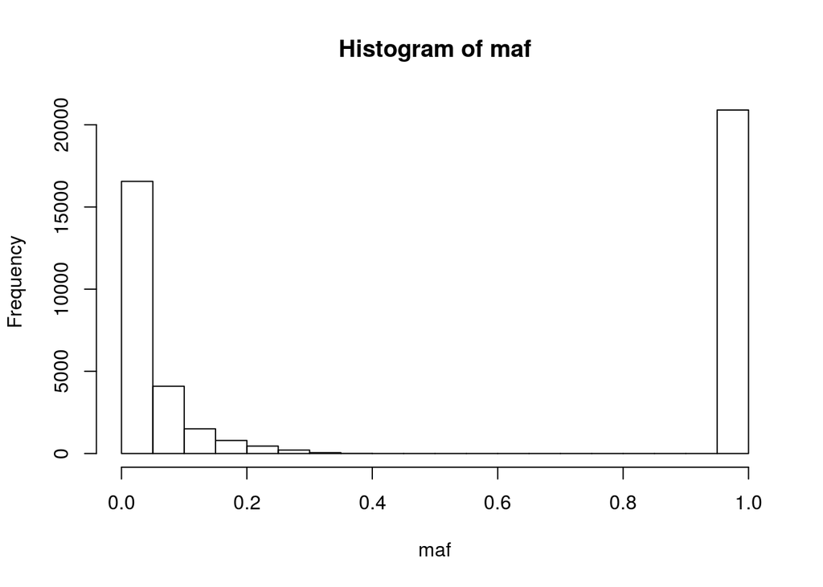

```r
maf <- apply(dnaCalls, 1, function(x) min(table(x)/length(x)))
hist(maf)
```

```r
dnaCalls <- dnaCalls[maf >= 0.01 & maf < 1,]
dim(dnaCalls)
```

```
## [1] 18040   103
```

Now we can run the allelesharing algorithm on the genotype data:

```r
library(omicsPrint)
data <- alleleSharing(dnaCalls)
```

```
## Hash relations
```

```
## Pruning 18040 SNPs ...
```

```
## 0 SNPs removed because of low call rate!
```

```
## 0 samples removed because too few SNPs called!
```

```
## Using 18040 polymorphic SNPs to determine allele sharing.
```

```
## Running `square` IBS algorithm!
```

```
## 104 of 5356 (1.94%) ...
```

```
## 5351 of 5356 (99.91%) ...
```

```r
mismatches <- inferRelations(data)
```

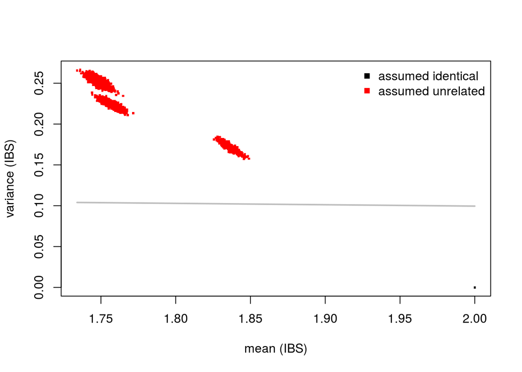

```r
mismatches
```

```
## [1] mean       var        colnames.x colnames.y relation   predicted
## <0 rows> (or 0-length row.names)
```

```r
nrow(data) ##number of pairs
```

```
## [1] 5356
```

```r
ncol(dnaCalls) ##identical
```

```
## [1] 103
```

```r
ncol(dnaCalls)*(ncol(dnaCalls) - 1)/2 ##non-identical
```

```
## [1] 5253
```

```r
ncol(dnaCalls)*(ncol(dnaCalls) + 1)/2 ##total
```

```
## [1] 5356
```

# Genotype and Methylation Data

To be able to run the allele sharing algorithm between the DNA methylation and genotype data there should be an overlapping set of SNPs.

Here we map probe identifiers to `chromosome:position`, like the enotype data using information for the array provider available from the [*FDb.InfiniumMethylation.hg19*](https://bioconductor.org/packages/FDb.InfiniumMethylation.hg19)-package, and rename to probes.

```r
library(FDb.InfiniumMethylation.hg19)
rngs <- getPlatform(platform='HM450', genome='hg19')
```

```
## Fetching coordinates for hg19...
```

```r
seqlevels(rngs) <- mapSeqlevels(seqlevels(rngs), "NCBI")

map <- names(rngs)
names(map) <- paste(seqnames(rngs),
                    mcols(rngs)$probeTarget, sep=":")

mid <- match(map, rownames(se))
rownames(se)[mid[!is.na(mid)]] <- names(map)[!is.na(mid)]

library(omicsPrint)
dnamCalls <- beta2genotype(se[rownames(se) %in% rownames(dnaCalls),], assayName = "exprs")
dnamCalls <- beta2genotype(se, assayName = "exprs")
dim(dnamCalls)
```

```
## [1] 8977  133
```

```r
dim(dnaCalls)
```

```
## [1] 18040   103
```

```r
data <- alleleSharing(dnamCalls, dnaCalls, phasing=TRUE)
```

```
## Hash relations
```

```
## Pruning 8977 SNPs ...
```

```
## 0 SNPs removed because of low call rate!
```

```
## 0 samples removed because too few SNPs called!
```

```
## Pruning 18040 SNPs ...
```

```
## 0 SNPs removed because of low call rate!
```

```
## 0 samples removed because too few SNPs called!
```

```
## Using 292 polymophic SNPs to determine allele sharing.
```

```
## Running `rectangular` IBS algorithm!
```

```
## 133 of 13699 (0.97%) ...
```

```
## 13300 of 13699 (97.09%) ...
```

```r
mismatches <- inferRelations(data)
```

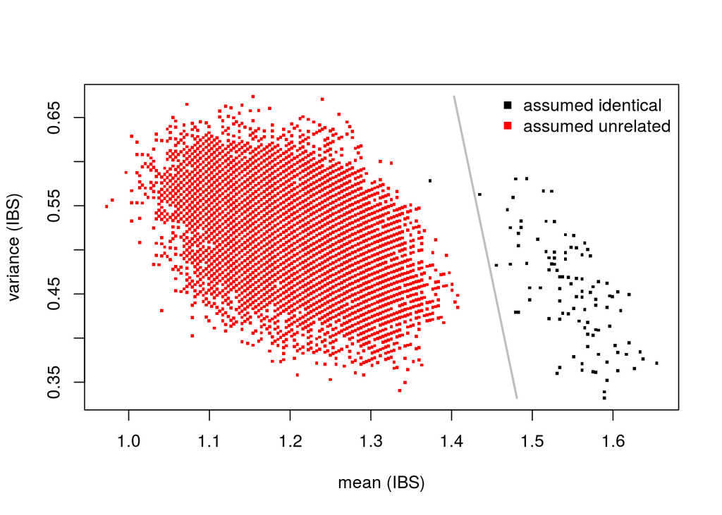

```r
mismatches
```

```
##          mean       var colnames.x colnames.y  relation predicted
## 7792 1.373288 0.5783905    NA12717    NA12717 identical unrelated
```

# Detect mislabelled samples

In order to show how mislabelled samples can be detected some mislabeling is artificially introduced, i.e. a known `identical` relation is removed and `unrelated` pair is set to identical.

```r
set.seed(12345)
relations <- expand.grid(idx = colnames(dnamCalls), idy = colnames(dnaCalls))
relations$relation_type <- "unrelated"
relations$relation_type[as.character(relations$idx) == as.character(relations$idy)] <- "identical"

id <- sample(which(relations$relation_type == "identical"), 10)
relations[id,]
```

```
##           idx     idy relation_type
## 9940  NA19114 NA19114     identical
## 11955 NA12815 NA12815     identical
## 10208 NA18853 NA18853     identical
## 11820 NA07000 NA07000     identical
## 6046  NA18858 NA18858     identical
## 2151  NA11881 NA11881     identical
## 4167  NA19099 NA19099     identical
## 6449  NA19159 NA19159     identical
## 9270  NA12763 NA12763     identical
## 12492 NA19172 NA19172     identical
```

```r
relations$relation_type[id] <- "unrelated"

id <- sample(which(relations$relation_type == "unrelated"), 10)
relations[id,]
```

```
##           idx     idy relation_type
## 474   NA12044 NA11829     unrelated
## 2090  NA11832 NA19209     unrelated
## 10079 NA19210 NA19093     unrelated
## 17    NA12814 NA19147     unrelated
## 5360  NA12874 NA19206     unrelated
## 6336  NA11992 NA12761     unrelated
## 5317  NA19225 NA12234     unrelated
## 5514  NA18858 NA18502     unrelated
## 2452  NA12762 NA18507     unrelated
## 13027 NA19238 NA19143     unrelated
```

```r
relations$relation_type[id] <- "identical"
relations <- relations[relations$relation_type == "identical",]

library(omicsPrint)
data <- alleleSharing(dnamCalls, dnaCalls, relations=relations, phasing=TRUE)
```

```
## Hash relations
```

```
## Pruning 8977 SNPs ...
```

```
## 0 SNPs removed because of low call rate!
```

```
## 0 samples removed because too few SNPs called!
```

```
## Pruning 18040 SNPs ...
```

```
## 0 SNPs removed because of low call rate!
```

```
## 0 samples removed because too few SNPs called!
```

```
## Using 292 polymophic SNPs to determine allele sharing.
```

```
## Running `rectangular` IBS algorithm!
```

```
## 133 of 13699 (0.97%) ...
```

```
## 13300 of 13699 (97.09%) ...
```

```r
mismatches <- inferRelations(data)
```

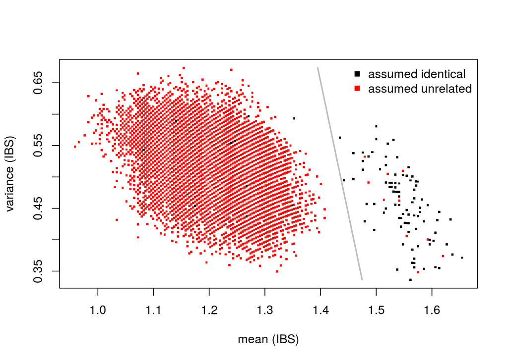

```r
mismatches
```

```
##           mean       var colnames.x colnames.y  relation predicted
## 17    1.160959 0.4722850    NA12814    NA19147 identical unrelated
## 474   1.270548 0.5966554    NA12044    NA11829 identical unrelated
## 2090  1.082192 0.5430495    NA11832    NA19209 identical unrelated
## 2151  1.520548 0.5047310    NA11881    NA11881 unrelated identical
## 2452  1.267123 0.4851010    NA12762    NA18507 identical unrelated
## 4167  1.619863 0.3738996    NA19099    NA19099 unrelated identical
## 5317  1.174658 0.4539260    NA19225    NA12234 identical unrelated
## 5360  1.140411 0.5884644    NA12874    NA19206 identical unrelated
## 5514  1.349315 0.4548793    NA18858    NA18502 identical unrelated
## 6046  1.592466 0.4003554    NA18858    NA18858 unrelated identical
## 6336  1.239726 0.5540178    NA11992    NA12761 identical unrelated
## 6449  1.541096 0.4622228    NA19159    NA19159 unrelated identical
## 7792  1.352740 0.5933602    NA12717    NA12717 identical unrelated
## 9270  1.486301 0.4912206    NA12763    NA12763 unrelated identical
## 9940  1.554795 0.4059220    NA19114    NA19114 unrelated identical
## 10079 1.246575 0.5575484    NA19210    NA19093 identical unrelated
## 10208 1.575342 0.3482559    NA18853    NA18853 unrelated identical
## 11820 1.479452 0.5322224    NA07000    NA07000 unrelated identical
## 11955 1.513699 0.4637292    NA12815    NA12815 unrelated identical
## 12492 1.547945 0.5097208    NA19172    NA19172 unrelated identical
## 13027 1.267123 0.4369910    NA19238    NA19143 identical unrelated
```

These mislabel samples (pairs) are automatically detected.

# Customized plots

Here we show some examples for creating customized plots of the mean and variance of IBS:

```r
data <- alleleSharing(dnaCalls)
plotdata <- inferRelations(data, plot.it=FALSE)

ped <- read.table("ftp://ftp.1000genomes.ebi.ac.uk/vol1/ftp/technical/working/20130606_sample_info/20130606_g1k.ped", header=TRUE, sep="\t")

plotdata$population.x <- plotdata$population.y <- "unknown"
mid <- match(plotdata$colnames.x, ped$Individual.ID)
plotdata$population.x <- ped$Population[mid]
mid <- match(plotdata$colnames.y, ped$Individual.ID)
plotdata$population.y <- ped$Population[mid]

colors <- factor(paste(plotdata$population.x, plotdata$population.y, sep="-"))
levels(colors)[grepl("NA", levels(colors))] <- "unknown"

levels(colors)[2] <- levels(colors)[3]
labels <- colors
table(colors)
levels(colors) <- c("red", "blue", "orange")

with(plotdata, {
    plot(mean, var, pch=18, col=adjustcolor(colors, alpha.f = 0.3),
         xlab="mean (IBS)", ylab="variance (IBS)")
    points(2, 0, pch=18, col="black")
    legend("topright", levels(labels), col=levels(colors), pch=18, bty="n")
     })

with(plotdata, {
    plot(mean, var, pch=18, col=colors,
         xlab="mean (IBS)", ylab="variance (IBS)")
    points(2, 0, pch=18, col="black")
    legend("topright", levels(labels), col=levels(colors), pch=18, bty="n")
     })

## with(plotdata, {
##     id <- which(predicted != relation)

##     levels(relation) <- c("black", "red")

##     plot(mean, var, pch=18, col=adjustcolor(relation, alpha.f = 0.3),
##          xlab="mean (IBS)", ylab="variance (IBS)")
##     points(mean[id], var[id], pch=18, col=relation[id])
##      })
```

[output not shown]

# Reference

Chen, Y. A., M. Lemire, S. Choufani, D. T. Butcher, D. Grafodatskaya, B. W. Zanke, S. Gallinger, T. J. Hudson, and R. Weksberg. 2013. “Discovery of cross-reactive probes and polymorphic CpGs in the Illumina Infinium HumanMethylation450 microarray.” *Epigenetics* 8 (2): 203–9.

Moen, E. L., X. Zhang, W. Mu, S. M. Delaney, C. Wing, J. McQuade, J. Myers, L. A. Godley, M. E. Dolan, and W. Zhang. 2013. “Genome-wide variation of cytosine modifications between European and African populations and the implications for complex traits.” *Genetics* 194 (4): 987–96.

Zhou, W., P. W. Laird, and H. Shen. 2016. “Comprehensive characterization, annotation and innovative use of Infinium DNA methylation BeadChip probes.” *Nucleic Acids Res.*, October.